# Data Science Summer Sessions

Let’s plot `pop` to the `y` axis instead.

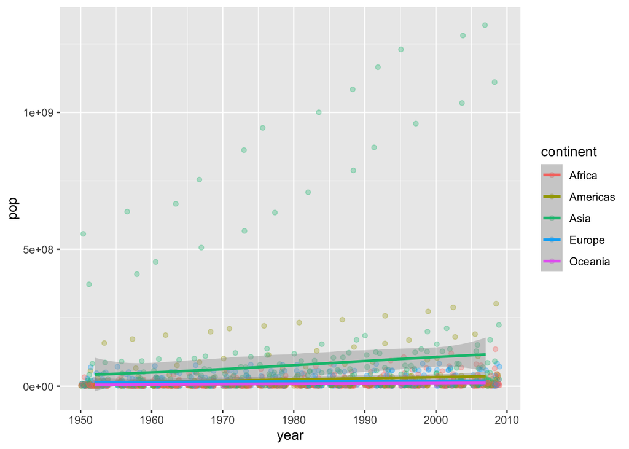

```r
gapminder %>%
  ggplot(aes(x = year,
             y = pop,
             color = continent)) +
  geom_jitter(alpha = .3) +
  geom_smooth()
```

There seems to be two countries in Asia that have a much high population than the other countries in the data. Can you guess what countries are those?

Let’s filter our data to keep only Asia, and try to visualize the data by country.

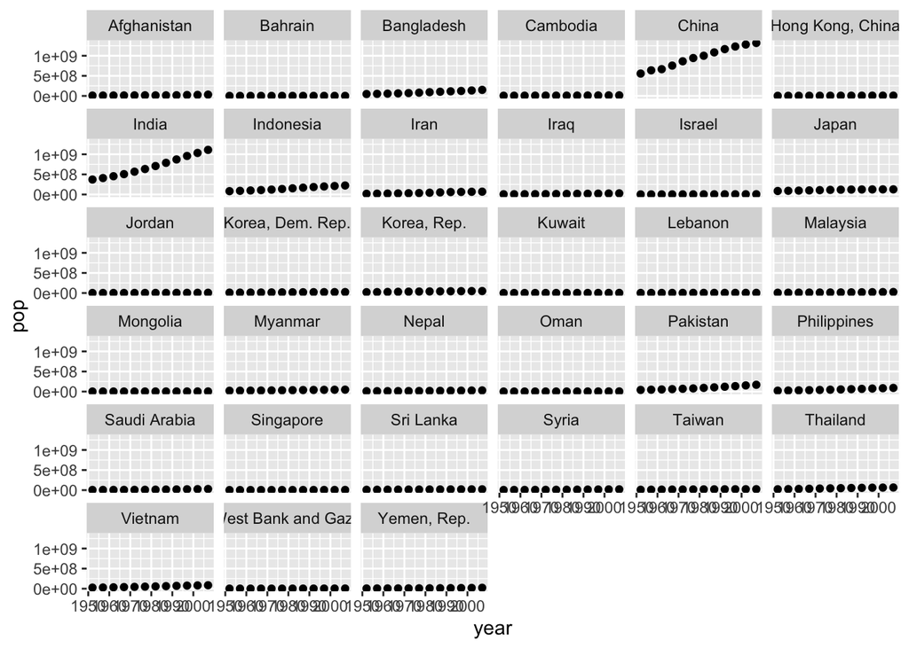

```r
gapminder %>%
  filter(continent == "Asia") %>%
  ggplot(aes(x = year,
             y = pop)) +
  geom_point() +
  facet_wrap(~country)
```

## 3.2 Plotting summarized data

The other option is to first aggregate or summarize data, and then plot the summarization. Let’s get the maximum `gdpPercap` for each continent.

```r
gapminder_aggregated <- gapminder %>%
  group_by(continent) %>%
  summarize(max_gdp = max(gdpPercap))
```

Inspect our results.

```r
gapminder_aggregated
```

```
## # A tibble: 5 × 2
##   continent max_gdp
##   <fct>       <dbl>
## 1 Africa     21951.
## 2 Americas   42952.
## 3 Asia      113523.
## 4 Europe     49357.
## 5 Oceania    34435.
```

We can also plot these results. Let’s do a bar plot this time around using `geom_col()`.

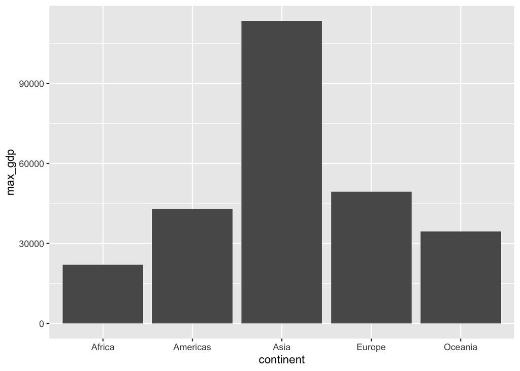

```r
gapminder_aggregated %>%
  ggplot(aes(x = continent,
             y = max_gdp)) +
  geom_col()
```

Continent is an unordered categorical variable, so let’s reorder continent by the numeric variable.

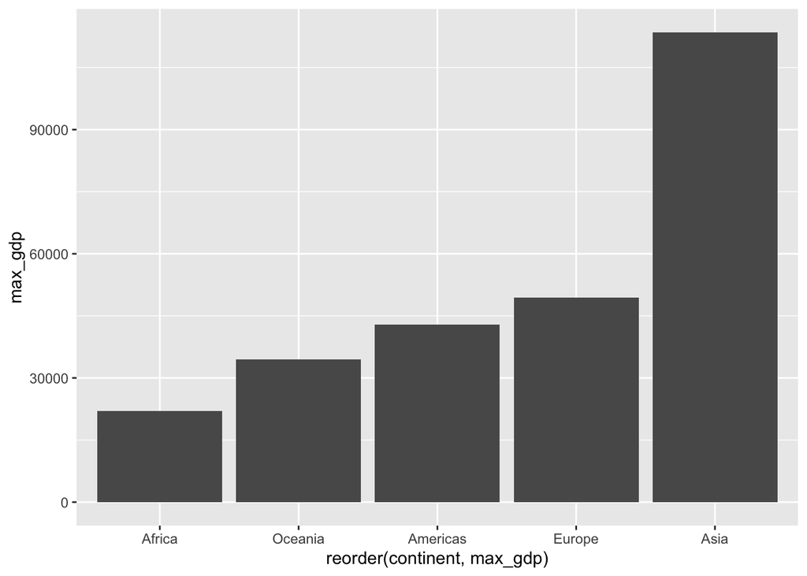

```r
gapminder_aggregated %>%
  ggplot(aes(x = reorder(continent, max_gdp),
             y = max_gdp)) +
  geom_col()
```

# 4 Video Demonstration

[video not shown]